# act_report

## Report: act_report

After my analysis of the twitter archive dataset of WeRateDogs, I was able to come up with these insights.

### Insights

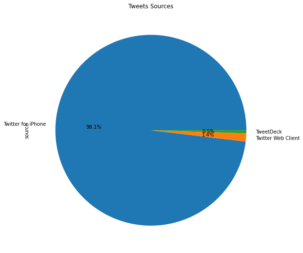

1. Of the four stages of dogs, the **doggo** stage received the highest grossing sum of likes from twitter users closely followed by **pupper**. I recommend that the handler of @dogs_rate posts more of doggos and puppers to get more reactions.

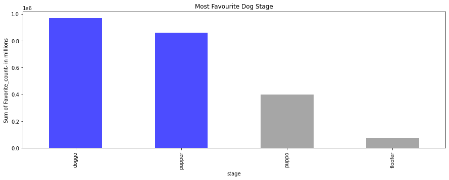

1. From my analysis, I gathered that retweet_counts and favorite_counts are **positively correlated**, though not perfectly but have a close coefficient correlation.I would encourage the twitter handler of WeRateDogs to post more audience engaging tweets. Any tweet retweeted, will most likely get more like reactions('favorite') .This will lead to more retweets and likes, and WeRateDogs will be able to reach a wider audience on Twitter.
- **Note**: This correlation does not mean causation

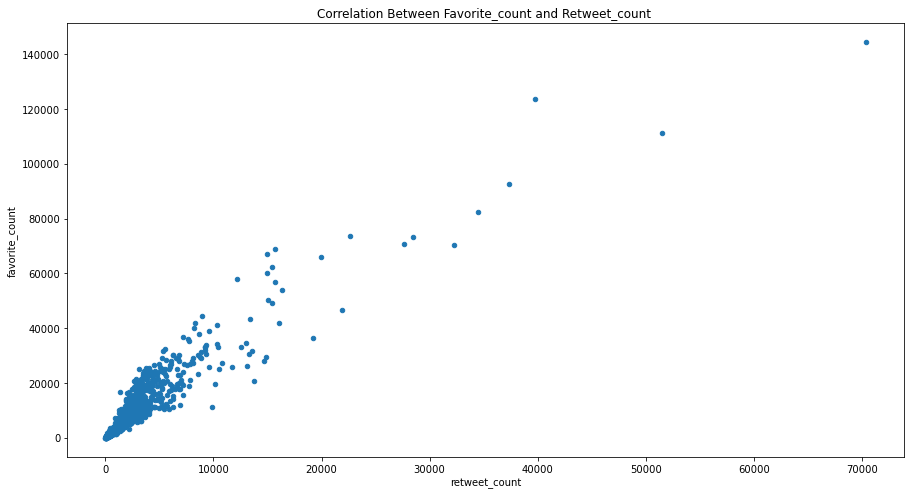

1. Also, my analysis shows that tweets made on **Wednesdays** received the highest average retweets and like reactions. While I am not recommending that @dogs_rate neglect other days as the bar chart shows that other days of the week also receive substantial retweets and like reactions, @dogs_rate should try to harness Wednesdays and release targeted tweets on that day.They can also try to add their promotions to the tweets made to get wider reach.

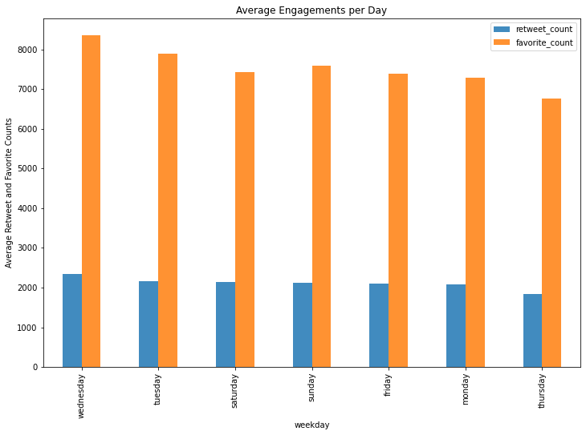